# Intro to linear models

We use models to explain the relationship between variables and to make predictions. For now we will focus on **linear** models (but remember there are other types of models too!)

Today, we will focus on fitting and interpreting models with a continuous outcome variable and a single predictor. To do so, we will use the `broom` package, which takes the messy output of built-in functions in R and turns them into tidy data frames. As expected, it integrates well with the tidyverse, especially with data wrangling using `dplyr`.

[figure not shown]

## Today’s data

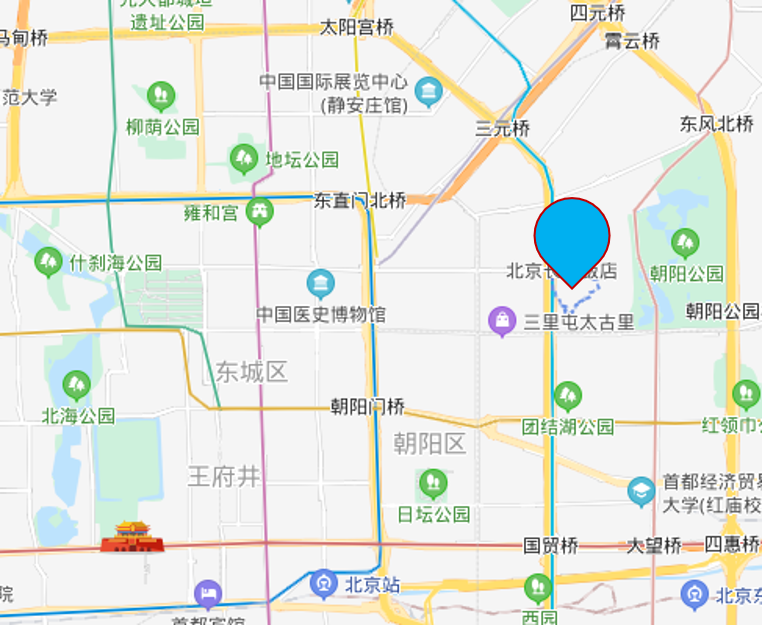

Today’s data are come from a series of atmospheric measurements taken at the Agriculture Exhibition Hall in Beijing from 2013 - 2017. The following variables are in the dataset:

- `year`, `month`, `day`, and `hour`: when the observation was taken
- `PM2.5` and `PM10`: levels of fine particulate matter in the atmosphere, in $\mu$g/m$^3$
- `SO2`, `NO2`, `CO`, `O3`: sulfur dioxide, nitrogen dioxide, carbon monoxide, and ozone concentrations, in $\mu$g/m$^3$, respectivel
- `TEMP`: temperature, in degrees C
- `PRES`: barometric pressure, in hPa
- `DEWP`: dew point temperature, in degrees C
- `RAIN`: precipitation levels, in mm
- `wd`: wind direction (eight compass directions)
- `SWPM`: wind speed, in m/s

These data are adapted from a dataset released by Song Xi Chen as referenced in Zhang S., et al (2017), Proc. Royal Soc. A. Let’s explore some of these data.

1. Describe the distribution of dew point as measured at this station (in degrees C):

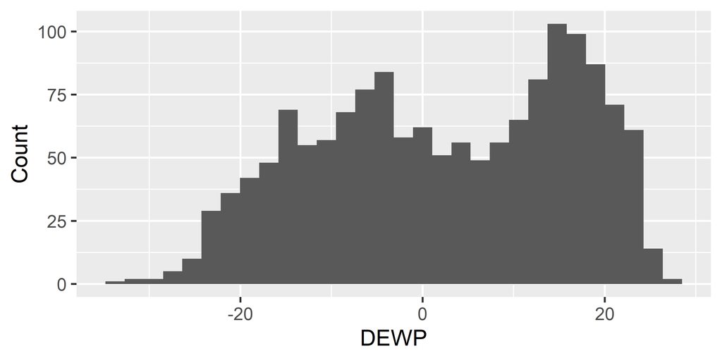

2. Describe the distribution of barometric pressure (in hectopascals):

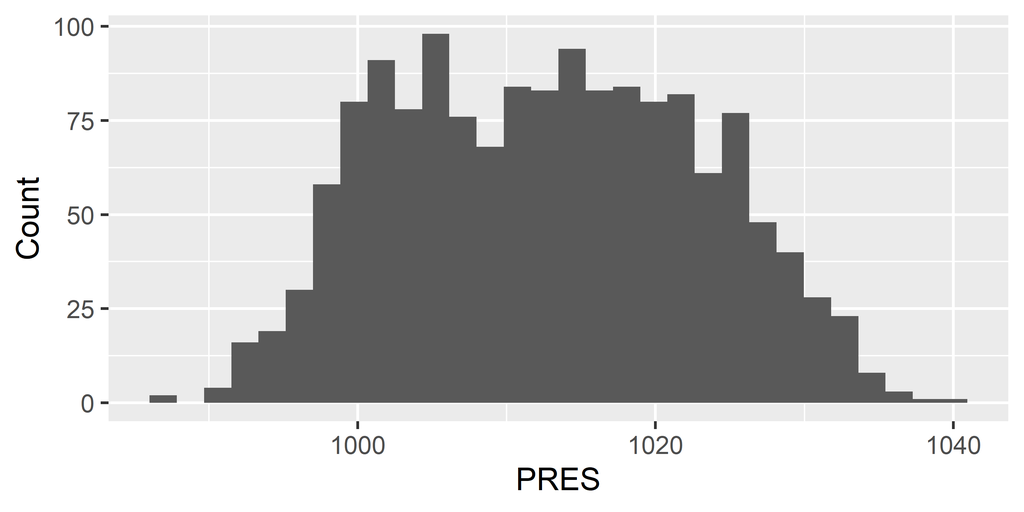

## Models as functions

We can represent relationships between variables using **functions**. A function in the *mathematical* sense is the relationship between one or more inputs and an output created from that (those) input(s). Essentially, we can “plug in” the inputs and receive back the output.

For instance, the formula $y = 3x + 7$ is a function with input $x$ and output $y$. When $x$ is $5$, the output $y$ is $22$:

```r
x <- 5
y <- 3*x + 7

y
```

```
## [1] 22
```

In statistical models, the **response variable** (dependent variable, or outcome variable) is the variable whose behavior or variation we are trying to understand, and is generally denoted by $y$. The **explanatory variable** (independent variable, or predictor variable) is the variable we want to use to explain the variation in the response, generally denoted by $x$.

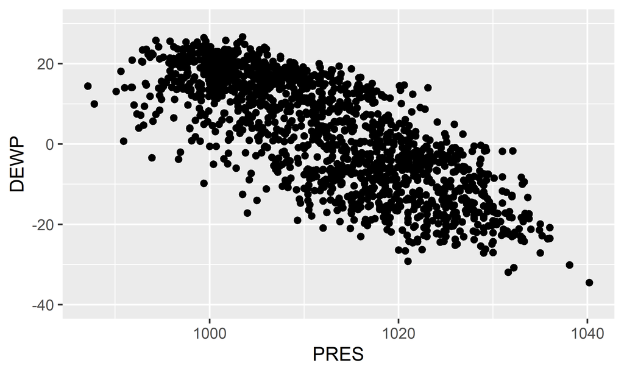

4. Now let’s overlay a line on this relationship. What are the response and explanatory variables? Does the line describe the relationship between these two variables “well”?

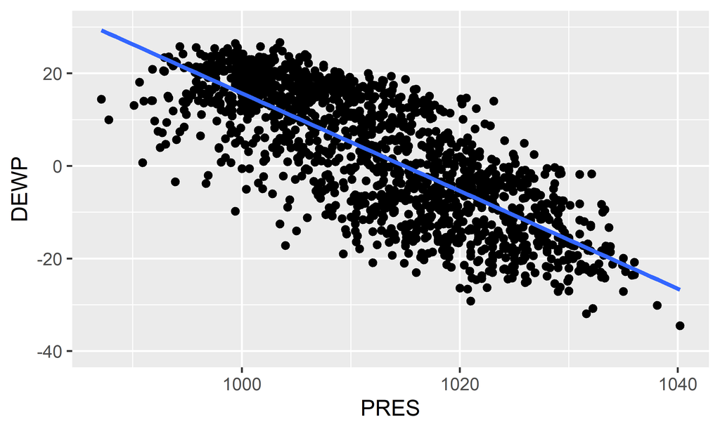

The blue line is a function that we can use to obtain **predicted values** of our response given values of our predictors. These predicted values are the output of the **model function**. That is, the expected value of the response *given* a certain value of the explanatory variable. However, we know that there is variability around our prediction (compare the line to the actual values). The **residual** is the difference between the actual observed value of the response variable *observed* in the dataset vs. the value *predicted* by the model. It is essentially the vertical distance between each point and the line.

5. What does a negative residual mean? Which points on the plot above have negative residuals?

## Interpreting linear models

As previously mentioned, we will be using the [`broom` package](https://broom.tidyverse.org/). Some of the most commonly used functions are as follows:

- **`tidy`**: Constructs a tidy data frame summarizing model’s statistical findings
- **`glance`**: Constructs a concise one-row summary of the model
- **`augment`**: Adds columns (e.g. predictions, residuals) to the original data that was modeled

Today, we will focus on making `tidy` regression output for linear models and `glance`ing at a model summary.

Let’s create a linear model that predicts the dew point given the current barometric pressure. We first use the `lm` function to create a **l**inear **m**odel object. Let’s create and save a model, `mod1`, for use in later downstream analyses:

```r
mod1 <- lm(DEWP ~ PRES, data = beijing)
```

Now let’s take a look at the `tidy` output for our object as provided by the `broom` package:

```r
tidy(mod1)
```

```
## # A tibble: 2 x 5
##   term        estimate std.error statistic   p.value
##   <chr>          <dbl>     <dbl>     <dbl>     <dbl>
## 1 (Intercept)  1071.     22.5         47.7 1.68e-302
## 2 PRES           -1.06    0.0222     -47.6 1.18e-301
```

Note that we “expect” these relationships to hold, but there will be some variability!

In general, we assume the following underlying simple linear model for a single predictor and a single continuous outcome:

$$y_i = \beta_0 + \beta_1x_i + \epsilon_i$$

$\beta_0$ and $\beta_1$ are **parameters** which aren’t observed (neither is the error, $\epsilon_i$). When we estimate these parameters, we denote these estimates with hats: $\hat{\beta}_0$ and $\hat{\beta}_1$. We often use **ordinary least squares** (OLS) to obtain these estimates to get the **fitted** model

$$\hat{y}_i = \hat{\beta}_0 + \hat{\beta}_1x_i$$

6. What is different between the underlying linear model and the fitted model?

Remember that residuals are the differences between the observed response and the predicted response values from the model:

$$\hat{\epsilon_i} = y_i - (\hat{\beta}_0 + \hat{\beta}_1x_i) = y_i - \hat{y}_i$$

OLS selects $\hat{\beta}_0$ and $\hat{\beta}_1$ such that the sum of squared residuals is minimized. The residuals are given by the red segments in the graphic below:

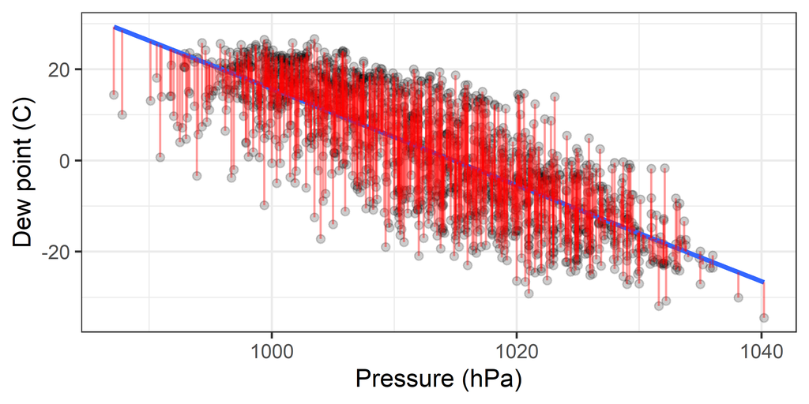

## Statistical inference

```
## # A tibble: 2 x 5
##   term        estimate std.error statistic   p.value
##   <chr>          <dbl>     <dbl>     <dbl>     <dbl>
## 1 (Intercept)  1071.     22.5         47.7 1.68e-302
## 2 PRES           -1.06    0.0222     -47.6 1.18e-301
```

You might have noticed a p-value corresponding to each of the parameter estimates $\hat{\beta}_0$ and $\hat{\beta}_1$ In regression models, p-values generally correspond to testing the null hypothesis
$$H_0: \beta = 0$$
vs. the alternative hypothesis
$$H_1: \beta \neq 0$$
.

7. At the $\alpha = 0.05$ level, is there sufficient evidence to suggest that $\beta_0 \neq 0$? How about $\beta_1$?

We can also get model-level summaries by using the `glance` function on our model object:

```r
glance(mod1)
```

```
## # A tibble: 1 x 11
##   r.squared adj.r.squared sigma statistic   p.value    df logLik    AIC    BIC
##       <dbl>         <dbl> <dbl>     <dbl>     <dbl> <int>  <dbl>  <dbl>  <dbl>
## 1     0.602         0.601  8.81     2262. 1.18e-301     2 -5391. 10788. 10804.
## # ... with 2 more variables: deviance <dbl>, df.residual <int>
```

$R^2$ (`r.squared` in the `glance` output) tells us the percentage of variability in the response variable that explained by our predictors. In our example, We see that approximately 60% of the variability in dew point can be explained by its linear relationship with barometric pressure.

## Categorical predictors?

Let’s fit a linear regression model using the categorical variable `wd` (wind direction), which takes on eight values corresponding to the compass points.

```r
mod2 <- lm(DEWP ~ wd, data = beijing)
tidy(mod2)
```

```
## # A tibble: 8 x 5
##   term        estimate std.error statistic  p.value
##   <chr>          <dbl>     <dbl>     <dbl>    <dbl>
## 1 (Intercept)    5.93      0.776     7.64  3.92e-14
## 2 wdN           -8.17      1.39     -5.86  5.77e- 9
## 3 wdNE          -3.84      1.08     -3.56  3.83e- 4
## 4 wdNW         -12.6       1.22    -10.2   7.23e-24
## 5 wdS            1.95      1.38      1.41  1.60e- 1
## 6 wdSE           0.312     1.36      0.230 8.18e- 1
## 7 wdSW          -2.10      1.21     -1.73  8.33e- 2
## 8 wdW           -5.41      1.59     -3.40  6.95e- 4
```

8. What do you think these “slopes” correspond to? Why are there only seven wind directions in the output but eight in total? what happened to wind coming from the east?

When the categorical explanatory variable has many levels, the levels are encoded as **dummy variables**. Dummy variables take values of either 0 or 1, depending on whether the condition it corresponds to is satisfied. For instance, `wdS` takes on the value of 1 if the wind comes from the south, and 0 if it does not. Each coefficient describes the expected difference in dew point when wind comes from that particular direction compared to the baseline level (east).

Our fitted/predicted model is given by

$$\begin{align*}
\widehat{DEWP} &= 5.93 - 8.17N - 3.84NE - 12.55NW + \\
&\mathrel{\phantom{=}} 1.95S + 0.31SE -2.10SW - 5.41W
\end{align*}$$
where the predictors correspond to dummy variables for if the wind is blowing from that direction.

9. Using the tidy model output above, is there sufficient evidence to suggest differences in dew point depending on wind direction? What patterns do you see?